# Lec09 Unsupervised Learning Mini Proj

Michael Nguyen

10/29/2019

# 1. Exploratory data analysis

## Data input

```r
read.csv("WisconsinCancer.csv")
```

[output not shown]

[output cut: 4545 more lines]

```r
# Save your input data file to a new 'data' directory
fna.data <- "data/WisconsinCancer.csv"
```

```r
wisc.df <-read.csv("WisconsinCancer.csv")
head(wisc.df)
```

```
##         id diagnosis radius_mean texture_mean perimeter_mean area_mean
## 1   842302         M       17.99        10.38         122.80    1001.0
## 2   842517         M       20.57        17.77         132.90    1326.0
## 3 84300903         M       19.69        21.25         130.00    1203.0
## 4 84348301         M       11.42        20.38          77.58     386.1
## 5 84358402         M       20.29        14.34         135.10    1297.0
## 6   843786         M       12.45        15.70          82.57     477.1
##   smoothness_mean compactness_mean concavity_mean concave.points_mean
## 1         0.11840          0.27760         0.3001             0.14710
## 2         0.08474          0.07864         0.0869             0.07017
## 3         0.10960          0.15990         0.1974             0.12790
## 4         0.14250          0.28390         0.2414             0.10520
## 5         0.10030          0.13280         0.1980             0.10430
## 6         0.12780          0.17000         0.1578             0.08089
##   symmetry_mean fractal_dimension_mean radius_se texture_se perimeter_se
```

[output cut: 41 more lines]

“`r” means Rcode!

Note that the `id` and `diagnosis`cols will not be used for most of the folllowing steps

we have 569 samples in the data set

```r
# Find number of pts.
nrow(wisc.df)
```

```
## [1] 569
```

```r
table(wisc.df$diagnosis)
```

```
##
##   B   M
## 357 212
```

```r
# Converting the features of the data: wisc.data
wisc.data <- as.matrix(wisc.df[,3:32])

# Set the row names of wisc.data
row.names(wisc.data) <- wisc.df$id
#head(wisc.data)
head(wisc.data)
```

```
##          radius_mean texture_mean perimeter_mean area_mean smoothness_mean
## 842302         17.99        10.38         122.80    1001.0         0.11840
## 842517         20.57        17.77         132.90    1326.0         0.08474
## 84300903       19.69        21.25         130.00    1203.0         0.10960
## 84348301       11.42        20.38          77.58     386.1         0.14250
## 84358402       20.29        14.34         135.10    1297.0         0.10030
## 843786         12.45        15.70          82.57     477.1         0.12780
##          compactness_mean concavity_mean concave.points_mean symmetry_mean
## 842302            0.27760         0.3001             0.14710        0.2419
## 842517            0.07864         0.0869             0.07017        0.1812
## 84300903          0.15990         0.1974             0.12790        0.2069
## 84348301          0.28390         0.2414             0.10520        0.2597
## 84358402          0.13280         0.1980             0.10430        0.1809
## 843786            0.17000         0.1578             0.08089        0.2087
##          fractal_dimension_mean radius_se texture_se perimeter_se area_se
```

[output cut: 41 more lines]

Store the diagnosis for references in the future as a separate vector

```r
# Create diagnosis vector for later
diagnosis <- wisc.df$diagnosis
```

Q1. How many observations are in this dataset? - 569 nrow(wisc.df)

Q2. How many of the observations have a malignant diagnosis? - 212 table(wisc.df)

Q3. How many variables/features in the data are suffixed with _mean?

```r
colnames(wisc.df)
```

```
##  [1] "id"                      "diagnosis"
##  [3] "radius_mean"             "texture_mean"
##  [5] "perimeter_mean"          "area_mean"
##  [7] "smoothness_mean"         "compactness_mean"
##  [9] "concavity_mean"          "concave.points_mean"
## [11] "symmetry_mean"           "fractal_dimension_mean"
## [13] "radius_se"               "texture_se"
## [15] "perimeter_se"            "area_se"
## [17] "smoothness_se"           "compactness_se"
## [19] "concavity_se"            "concave.points_se"
## [21] "symmetry_se"             "fractal_dimension_se"
## [23] "radius_worst"            "texture_worst"
## [25] "perimeter_worst"         "area_worst"
## [27] "smoothness_worst"        "compactness_worst"
## [29] "concavity_worst"         "concave.points_worst"
## [31] "symmetry_worst"          "fractal_dimension_worst"
## [33] "X"
```

```r
grep("_mean", colnames(wisc.df))
```

```
##  [1]  3  4  5  6  7  8  9 10 11 12
```

```r
length(grep("_mean", colnames(wisc.df)))
```

```
## [1] 10
```

These functions may be useful for answering the first 3 questions above. dim() - gives ROWS x COLs, nrow() - gives the number of rows, table() - gives us table by cross-classifying factors, length()- “size” of data you want to know grep() - pattern matching

# 2. PCA

## Performing PCA

The next step in your analysis is to perform principal component analysis (PCA) on wisc.data.

It is important to check if the data need to be scaled before performing PCA. Recall two common reasons for scaling data include:

The input variables use different units of measurement. The input variables have significantly different variances. Check the mean and standard deviation of the features (i.e. columns) of the wisc.data to determine if the data should be scaled. Use the colMeans() and apply() functions like you’ve done before

```r
# Check column means and standard deviations
colMeans(wisc.data)
```

```
##             radius_mean            texture_mean          perimeter_mean
##            1.412729e+01            1.928965e+01            9.196903e+01
##               area_mean         smoothness_mean        compactness_mean
##            6.548891e+02            9.636028e-02            1.043410e-01
##          concavity_mean     concave.points_mean           symmetry_mean
##            8.879932e-02            4.891915e-02            1.811619e-01
##  fractal_dimension_mean               radius_se              texture_se
##            6.279761e-02            4.051721e-01            1.216853e+00
##            perimeter_se                 area_se           smoothness_se
##            2.866059e+00            4.033708e+01            7.040979e-03
##          compactness_se            concavity_se       concave.points_se
##            2.547814e-02            3.189372e-02            1.179614e-02
##             symmetry_se    fractal_dimension_se            radius_worst
##            2.054230e-02            3.794904e-03            1.626919e+01
##           texture_worst         perimeter_worst              area_worst
##            2.567722e+01            1.072612e+02            8.805831e+02
##        smoothness_worst       compactness_worst         concavity_worst
##            1.323686e-01            2.542650e-01            2.721885e-01
##    concave.points_worst          symmetry_worst fractal_dimension_worst
##            1.146062e-01            2.900756e-01            8.394582e-02
```

```r
apply(wisc.data,2,sd)
```

```
##             radius_mean            texture_mean          perimeter_mean
##            3.524049e+00            4.301036e+00            2.429898e+01
##               area_mean         smoothness_mean        compactness_mean
##            3.519141e+02            1.406413e-02            5.281276e-02
##          concavity_mean     concave.points_mean           symmetry_mean
##            7.971981e-02            3.880284e-02            2.741428e-02
##  fractal_dimension_mean               radius_se              texture_se
##            7.060363e-03            2.773127e-01            5.516484e-01
##            perimeter_se                 area_se           smoothness_se
##            2.021855e+00            4.549101e+01            3.002518e-03
##          compactness_se            concavity_se       concave.points_se
##            1.790818e-02            3.018606e-02            6.170285e-03
##             symmetry_se    fractal_dimension_se            radius_worst
##            8.266372e-03            2.646071e-03            4.833242e+00
##           texture_worst         perimeter_worst              area_worst
##            6.146258e+00            3.360254e+01            5.693570e+02
##        smoothness_worst       compactness_worst         concavity_worst
##            2.283243e-02            1.573365e-01            2.086243e-01
##    concave.points_worst          symmetry_worst fractal_dimension_worst
##            6.573234e-02            6.186747e-02            1.806127e-02
```

THEY LOOK DIFFERENT… can try:

```r
round(colMeans(wisc.data), 3)
```

```
##             radius_mean            texture_mean          perimeter_mean
##                  14.127                  19.290                  91.969
##               area_mean         smoothness_mean        compactness_mean
##                 654.889                   0.096                   0.104
##          concavity_mean     concave.points_mean           symmetry_mean
##                   0.089                   0.049                   0.181
##  fractal_dimension_mean               radius_se              texture_se
##                   0.063                   0.405                   1.217
##            perimeter_se                 area_se           smoothness_se
##                   2.866                  40.337                   0.007
##          compactness_se            concavity_se       concave.points_se
##                   0.025                   0.032                   0.012
##             symmetry_se    fractal_dimension_se            radius_worst
##                   0.021                   0.004                  16.269
##           texture_worst         perimeter_worst              area_worst
##                  25.677                 107.261                 880.583
##        smoothness_worst       compactness_worst         concavity_worst
##                   0.132                   0.254                   0.272
##    concave.points_worst          symmetry_worst fractal_dimension_worst
##                   0.115                   0.290                   0.084
```

```r
round(apply(wisc.data, 2, sd), 3)
```

```
##             radius_mean            texture_mean          perimeter_mean
##                   3.524                   4.301                  24.299
##               area_mean         smoothness_mean        compactness_mean
##                 351.914                   0.014                   0.053
##          concavity_mean     concave.points_mean           symmetry_mean
##                   0.080                   0.039                   0.027
##  fractal_dimension_mean               radius_se              texture_se
##                   0.007                   0.277                   0.552
##            perimeter_se                 area_se           smoothness_se
##                   2.022                  45.491                   0.003
##          compactness_se            concavity_se       concave.points_se
##                   0.018                   0.030                   0.006
##             symmetry_se    fractal_dimension_se            radius_worst
##                   0.008                   0.003                   4.833
##           texture_worst         perimeter_worst              area_worst
##                   6.146                  33.603                 569.357
##        smoothness_worst       compactness_worst         concavity_worst
##                   0.023                   0.157                   0.209
##    concave.points_worst          symmetry_worst fractal_dimension_worst
##                   0.066                   0.062                   0.018
```

MEANS and with SD are different! therefore `scale = TRUE`

```r
# Perform PCA on wisc.data by completing the following code
wisc.pr <- prcomp(wisc.data, scale = TRUE)
summary(wisc.pr)
```

```
## Importance of components:
##                           PC1    PC2     PC3     PC4     PC5     PC6
## Standard deviation     3.6444 2.3857 1.67867 1.40735 1.28403 1.09880
## Proportion of Variance 0.4427 0.1897 0.09393 0.06602 0.05496 0.04025
## Cumulative Proportion  0.4427 0.6324 0.72636 0.79239 0.84734 0.88759
##                            PC7     PC8    PC9    PC10   PC11    PC12
## Standard deviation     0.82172 0.69037 0.6457 0.59219 0.5421 0.51104
## Proportion of Variance 0.02251 0.01589 0.0139 0.01169 0.0098 0.00871
## Cumulative Proportion  0.91010 0.92598 0.9399 0.95157 0.9614 0.97007
##                           PC13    PC14    PC15    PC16    PC17    PC18
## Standard deviation     0.49128 0.39624 0.30681 0.28260 0.24372 0.22939
## Proportion of Variance 0.00805 0.00523 0.00314 0.00266 0.00198 0.00175
## Cumulative Proportion  0.97812 0.98335 0.98649 0.98915 0.99113 0.99288
##                           PC19    PC20   PC21    PC22    PC23   PC24
## Standard deviation     0.22244 0.17652 0.1731 0.16565 0.15602 0.1344
## Proportion of Variance 0.00165 0.00104 0.0010 0.00091 0.00081 0.0006
## Cumulative Proportion  0.99453 0.99557 0.9966 0.99749 0.99830 0.9989
##                           PC25    PC26    PC27    PC28    PC29    PC30
## Standard deviation     0.12442 0.09043 0.08307 0.03987 0.02736 0.01153
## Proportion of Variance 0.00052 0.00027 0.00023 0.00005 0.00002 0.00000
## Cumulative Proportion  0.99942 0.99969 0.99992 0.99997 1.00000 1.00000
```

==> Look at *Cumulative Proportion* Q4. From your results, what proportion of the original variance is captured by the first principal components (PC1)? - 0.4427

Q5. How many principal components (PCs) are required to describe at least 70% of the original variance in the data? - 3

Q6. How many principal components (PCs) are required to describe at least 90% of the original variance in the data? - 7

```r
P <- summary(wisc.pr)
which(P$importance[3,] >0.9)[1]
```

```
## PC7
##   7
```

```r
# or `P$importance[row, col][1]
```

Has some structure. Useful to inspect. PC1 vs. PC2 = 60%

## Interpreting PCA results

Now you will use some visualizations to better understand your PCA model. A common visualization for PCA results is the so-called biplot.

However, you will often run into some common challenges with using biplots on real-world data containing a non-trivial number of observations and variables. Here we will need to look at some alternative visualizations. You are encouraged to experiment with additional visualizations before moving on to the next section

Create a biplot of the wisc.pr using the biplot() function.

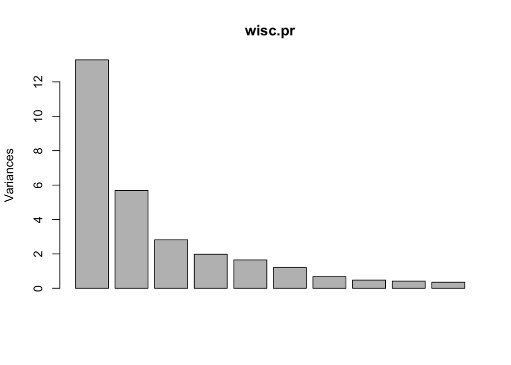

```r
plot(wisc.pr)
```

let’s make a plot of PC1 vs. PC2 (with color)

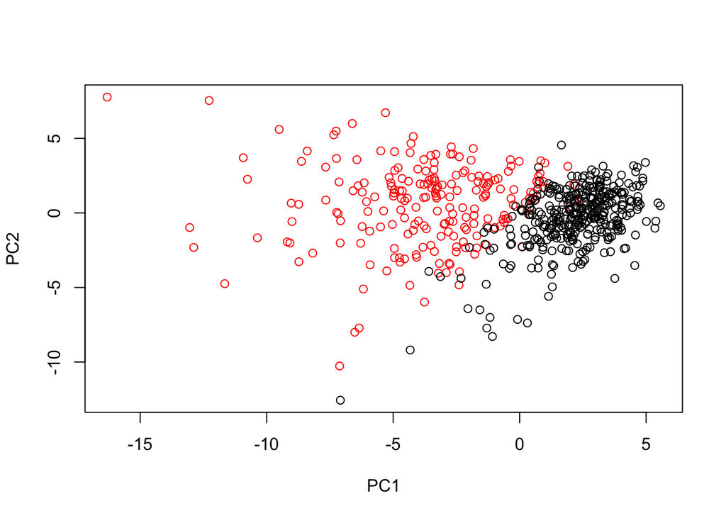

```r
plot(wisc.pr$x[,1], wisc.pr$x[,2], col = diagnosis, xlab = "PC1", ylab = "PC2")
```

Results = are like whoa. There is a split between cancer and malignant cancer diagnosis.

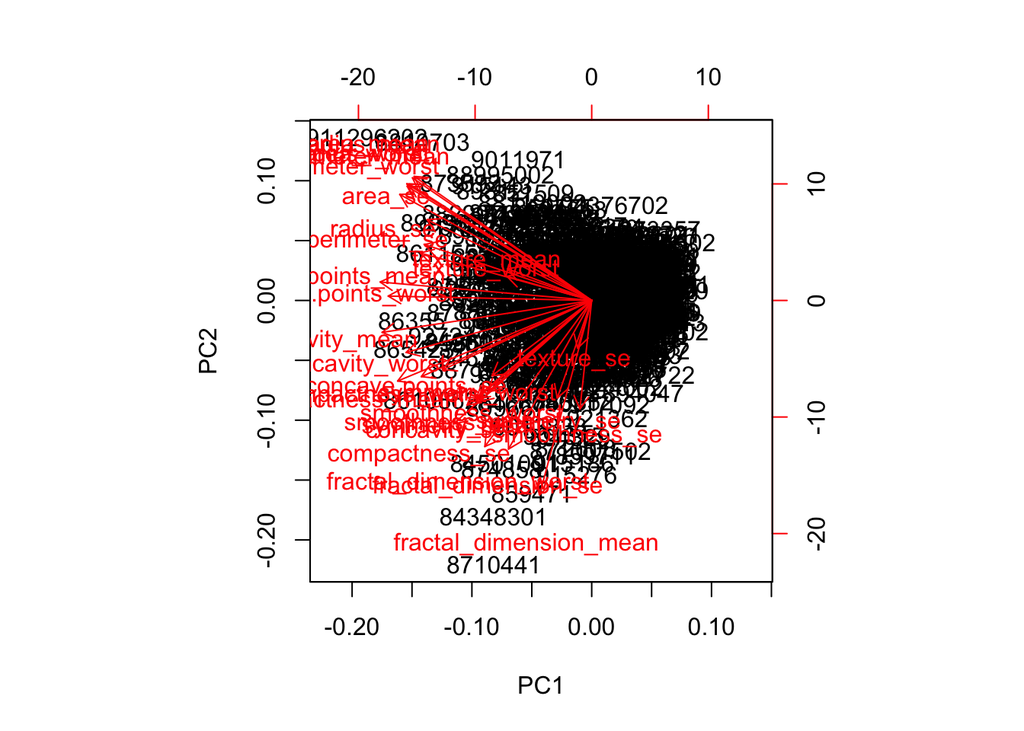

```r
biplot(wisc.pr)
```

Q7. What stands out to you about this plot? Is it easy or difficult to understand? Why? - It’s messy and difficult to interpret… CRAP

Q8. Generate a similar plot for principal components 1 and 3. What do you notice about these plots? - It’s somewhat the same as PC1 vs. PC2, but lower.

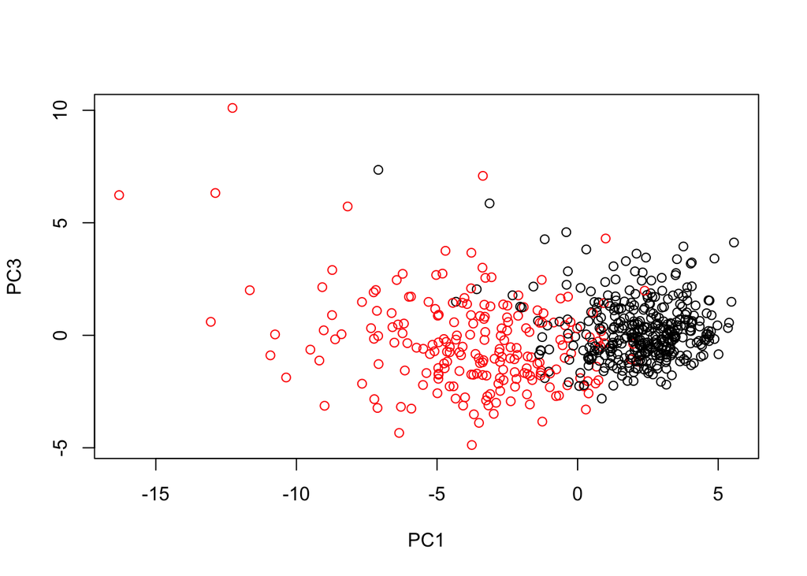

```r
plot(wisc.pr$x[,1], wisc.pr$x[,3], col = diagnosis, xlab = "PC1", ylab = "PC3")
```

Because principal component 2 explains more variance in the original data than principal component 3, you can see that the **first plot has a cleaner cut separating** the two subgroups.

### Overall, the plots indicate that principal component 1 is capturing a separation of malignant from benign samples. This is an important and interesting result worthy of further exploration - as we will do in the next sections!

## Variance explained

As you look at these plots, ask yourself if there’s an ‘elbow’ in the amount of variance explained that might lead you to pick a natural number of principal components. If an obvious elbow does not exist, as is typical in some real-world datasets, consider how else you might determine the number of principal components to retain based on the scree plot.

```r
# Calculate variance of each component
pr.var <- wisc.pr$sdev^2
head(pr.var)
```

```
## [1] 13.281608  5.691355  2.817949  1.980640  1.648731  1.207357
```

# 3. Hierarchical Clustering

## Hierarchical clustering of case data

The goal of this section is to do hierarchical clustering of the observations. Recall from our last class that this type of clustering does not assume in advance the number of natural groups that exist in the data.

As part of the preparation for hierarchical clustering, the distance between all pairs of observations are computed. Furthermore, there are different ways to link clusters together, with single, complete, and average being the most common linkage methods.

Scale the wisc.data data and assign the result to data.scaled.

```r
# Scale the wisc.data data: data.scaled
data.scaled <- scale(wisc.data)
```

```r
# Calculate the (Euclidean) distances between all pairs of observations in the new scaled dataset and assign the result to data.dist.
data.dist <- dist(data.scaled)

# Create a hierarchical clustering model using complete linkage. Manually specify the method argument to hclust() and assign the results to wisc.hclust.
wisc.hclust <- hclust(d = data.dist, method = "complete")
```

## Results of hierarchical clustering

Let’s use the hierarchical clustering model you just created to determine a height (or distance between clusters) where a certain number of clusters exists.

Q11. Using the plot() and abline() functions, what is the height at which the clustering model has 4 clusters?

- h = 19

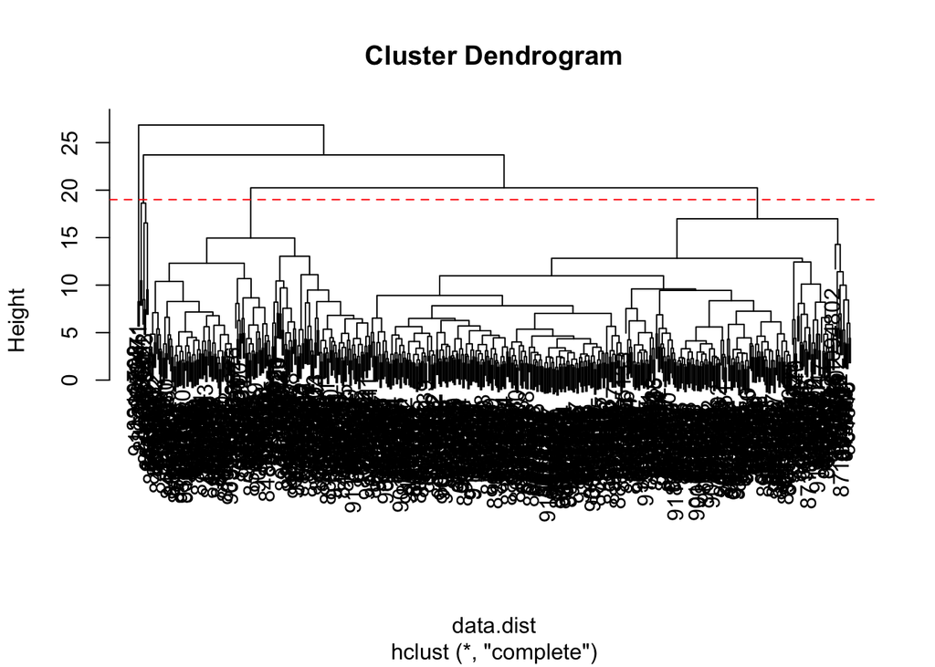

```r
plot(wisc.hclust)
abline(h = 19, col="red", lty=2)
```

## Selecting number of clusters

In this section, you will compare the outputs from your hierarchical clustering model to the actual diagnoses. Normally when performing unsupervised learning like this, a target variable (i.e. known answer or labels) isn’t available. We do have it with this dataset, however, so it can be used to check the performance of the clustering model.

When performing supervised learning - that is, when you’re trying to predict some target variable of interest and that target variable is available in the original data - using clustering to create new features may or may not improve the performance of the final model.

This exercise will help you determine if, in this case, hierarchical clustering provides a promising new feature.

Use cutree() to cut the tree so that it has 4 clusters. Assign the output to the variable wisc.hclust.clusters.

```r
wisc.hclust.clusters <- cutree(wisc.hclust, k = 4)
wisc.hclust.clusters
```

```
##    842302    842517  84300903  84348301  84358402    843786    844359
##         1         1         1         2         1         1         1
##  84458202    844981  84501001    845636  84610002    846226    846381
##         1         1         2         3         1         1         3
##  84667401  84799002    848406  84862001    849014   8510426   8510653
##         1         1         3         1         1         3         3
##   8510824   8511133    851509    852552    852631    852763    852781
##         3         1         1         1         1         1         1
##    852973    853201    853401    853612  85382601    854002    854039
##         1         3         1         1         1         1         1
##    854253    854268    854941    855133    855138    855167    855563
##         1         1         3         3         1         3         1
##    855625    856106  85638502    857010  85713702     85715    857155
##         1         1         1         1         3         1         3
##    857156    857343    857373    857374    857392    857438  85759902
```

[output cut: 149 more lines]

We can use the table() function to compare the cluster membership to the actual diagnoses.

```r
table(wisc.hclust.clusters, diagnosis)
```

```
##                     diagnosis
## wisc.hclust.clusters   B   M
##                    1  12 165
##                    2   2   5
##                    3 343  40
##                    4   0   2
```

Here we picked four clusters and see that cluster 1 largely corresponds to malignant cells (with diagnosis values of 1) whilst cluster 3 largely corresponds to benign cells (with diagnosis values of 0).

Before moving on, explore how different numbers of clusters affect the ability of the hierarchical clustering to separate the different diagnoses.

Q12. Can you find a better cluster vs diagnoses match with by cutting into a different number of clusters between 2 and 10?

- When you change the number clusters (k-value) it shows different number of clusters of different specificities. Too little of a k-value results in false posisitves while too high of a number results in better separation but too many spcifics can be confusing.

# 4. OPTIONAL: K-means clustering

K-means clustering and comparing results As you now know, there are two main types of clustering: hierarchical and k-means.

In this section, you will create a k-means clustering model on the Wisconsin breast cancer data and compare the results to the actual diagnoses and the results of your hierarchical clustering model. Take some time to see how each clustering model performs in terms of separating the two diagnoses and how the clustering models compare to each other.

Create a k-means model on wisc.data, assigning the result to wisc.km. Be sure to create 2 clusters, corresponding to the actual number of diagnosis. Also, remember to scale the data (with the scale() function and repeat the algorithm 20 times (by setting setting the value of the nstart argument appropriately). Running multiple times such as this will help to find a well performing model.

```r
wisc.km <- kmeans(wisc.data, centers= 2, nstart= 20)
wisc.km
```

```
## K-means clustering with 2 clusters of sizes 131, 438
##
## Cluster means:
##   radius_mean texture_mean perimeter_mean area_mean smoothness_mean
## 1    19.37992     21.69458      128.23130 1185.9298       0.1012946
## 2    12.55630     18.57037       81.12347  496.0619       0.0948845
##   compactness_mean concavity_mean concave.points_mean symmetry_mean
## 1       0.14861298     0.17693947          0.10069878     0.1915397
## 2       0.09109982     0.06243776          0.03343254     0.1780580
##   fractal_dimension_mean radius_se texture_se perimeter_se  area_se
## 1             0.06060290 0.7428038   1.222538     5.250580 95.67817
## 2             0.06345402 0.3041909   1.215153     2.152881 23.78529
##   smoothness_se compactness_se concavity_se concave.points_se symmetry_se
## 1   0.006598687     0.03217669   0.04241977        0.01567398  0.02030397
## 2   0.007173263     0.02347469   0.02874551        0.01063632  0.02061358
```

[output cut: 185 more lines]

```r
# Use the table() function to compare the cluster membership of the k-means model (wisc.km$cluster) to the actual diagnoses contained in the diagnosis vector.

table(wisc.km$cluster, diagnosis)
```

```
##    diagnosis
##       B   M
##   1   1 130
##   2 356  82
```

```r
#wisc.km$cluster vs. wisc.hclust.clusters
table(wisc.hclust.clusters, wisc.km$cluster)
```

```
##
## wisc.hclust.clusters   1   2
##                    1 109  68
##                    2   2   5
##                    3  18 365
##                    4   2   0
```

# 5 Combining methods

Clustering on PCA results In this final section, you will put together several steps you used earlier and, in doing so, you will experience some of the creativity and open endedness that is typical in unsupervised learning.

Recall from earlier sections that the PCA model required significantly fewer features to describe 70%, 80% and 95% of the variability of the data. In addition to normalizing data and potentially avoiding over-fitting, PCA also uncorrelates the variables, sometimes improving the performance of other modeling techniques.

Let’s see if PCA improves or degrades the performance of hierarchical clustering.

Using the minimum number of principal components required to describe at least 90% of the variability in the data, create a hierarchical clustering model with the linkage method=“ward.D2”. We use Ward’s criterion here because it is based on multidimensional variance like principal components analysis. Assign the results to wisc.pr.hclust.

```r
wisc.pr.hclust <- hclust(dist(wisc.pr$x[,1:7]), method = "ward.D2")
grps <- cutree(wisc.pr.hclust, k=2)
table(grps)
```

```
## grps
##   1   2
## 216 353
```

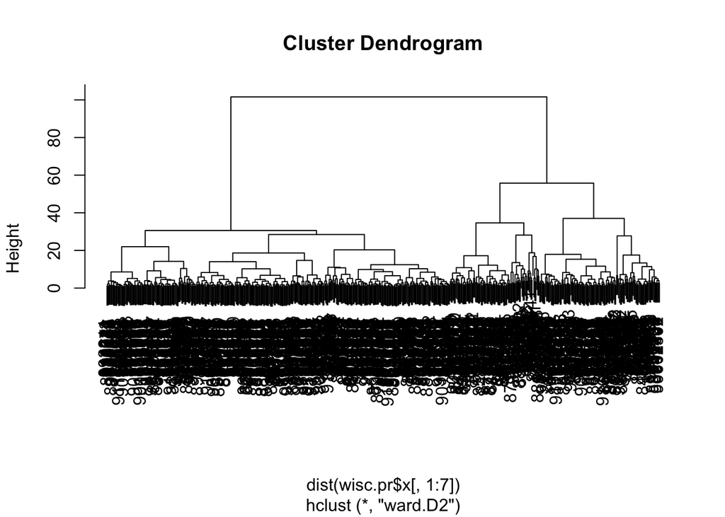

```r
plot(hclust(dist(wisc.pr$x[,1:7]), method = "ward.D2"))
```

```r
table(grps, diagnosis)
```

```
##     diagnosis
## grps   B   M
##    1  28 188
##    2 329  24
```

```r
# Sum Row 1 = 216!, same with Row 2 (353)
```

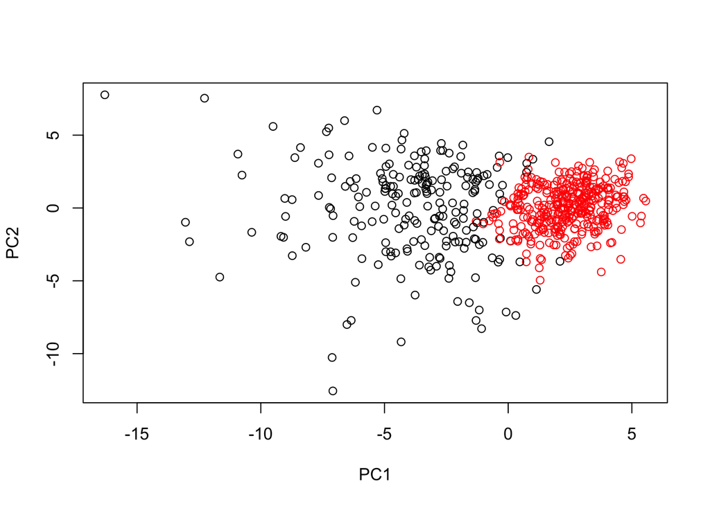

```r
plot(wisc.pr$x[,1:2], col=grps)
```

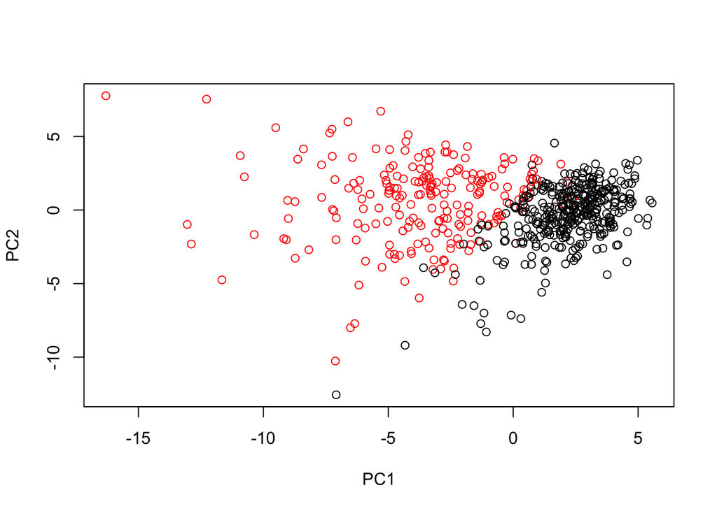

```r
plot(wisc.pr$x[,1:2], col=diagnosis)
```

```r
# Note the color swap here as the hclust cluster 1 is mostly “M” and cluster 2 is mostly “B” as we saw from the results of calling table(grps, diagnosis). To match things up we can turn our groups into a factor and reorder the levels so cluster 2 comes first
```

```r
g <- as.factor(grps)
levels(g)
```

```
## [1] "1" "2"
```

```r
# Space
g <- relevel(g,2)
levels(g)
```

```
## [1] "2" "1"
```

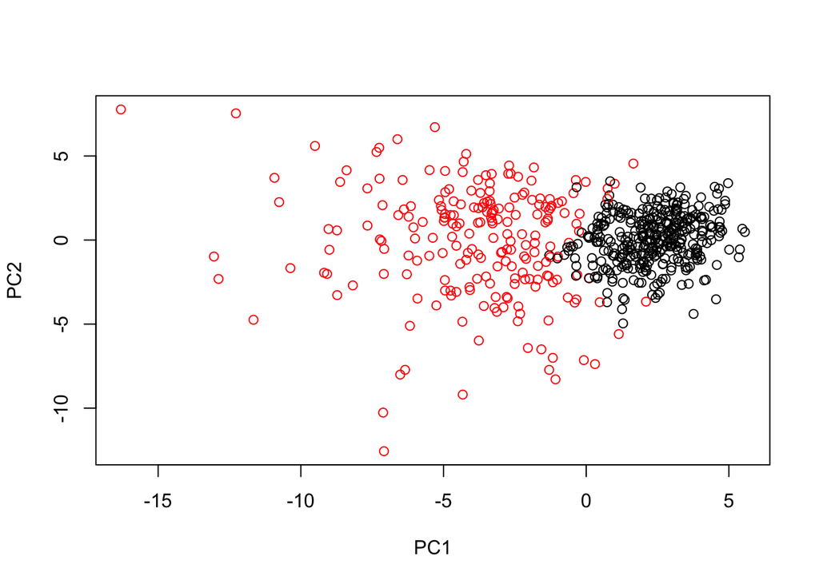

```r
# Plot using our re-ordered factor
plot(wisc.pr$x[,1:2], col=g)
```

```r
library(rgl)
```

```r
plot3d(wisc.pr$x[,1:3], xlab="PC 1", ylab="PC 2", zlab="PC 3", cex=1.5, size=1, type="s", col=grps)
rglwidget(width = 400, height = 400)
```

[interactive chart not shown]

To include the interactive rgl plot in your HTML renderd lab report you can add the R code `rglwidget(width = 400, height = 400)` after you call the plot3d() function. It will look just like the plot above. Try rotating and zooming on this 3D plot.

Q14. How well does the newly created model with four clusters separate out the two diagnoses? - It separates out them okay

Q15. How well do the k-means and hierarchical clustering models you created in previous sections (i.e. before PCA) do in terms of separating the diagnoses? Again, use the table() function to compare the output of each model (wisc.km$cluster and wisc.hclust.clusters) with the vector containing the actual diagnoses. - We got somoe false positives (healthy in cancerous cell populations and v.v.)

# 6.

# 7. Prediction

We will use the `predict()` function that will take our PCA model from before and new cancer cell data and project that data onto our PCA space.

```r
#url <- "new_samples.csv"
url <- "https://tinyurl.com/new-samples-CSV"
new <- read.csv(url)
npc <- predict(wisc.pr, newdata=new)
npc
```

```
##            PC1       PC2        PC3        PC4       PC5        PC6
## [1,]  2.576616 -3.135913  1.3990492 -0.7631950  2.781648 -0.8150185
## [2,] -4.754928 -3.009033 -0.1660946 -0.6052952 -1.140698 -1.2189945
##             PC7        PC8       PC9       PC10      PC11      PC12
## [1,] -0.3959098 -0.2307350 0.1029569 -0.9272861 0.3411457  0.375921
## [2,]  0.8193031 -0.3307423 0.5281896 -0.4855301 0.7173233 -1.185917
##           PC13     PC14      PC15       PC16        PC17        PC18
## [1,] 0.1610764 1.187882 0.3216974 -0.1743616 -0.07875393 -0.11207028
## [2,] 0.5893856 0.303029 0.1299153  0.1448061 -0.40509706  0.06565549
##             PC19       PC20       PC21       PC22       PC23       PC24
## [1,] -0.08802955 -0.2495216  0.1228233 0.09358453 0.08347651  0.1223396
## [2,]  0.25591230 -0.4289500 -0.1224776 0.01732146 0.06316631 -0.2338618
##             PC25         PC26         PC27        PC28         PC29
## [1,]  0.02124121  0.078884581  0.220199544 -0.02946023 -0.015620933
## [2,] -0.20755948 -0.009833238 -0.001134152  0.09638361  0.002795349
##              PC30
## [1,]  0.005269029
## [2,] -0.019015820
```

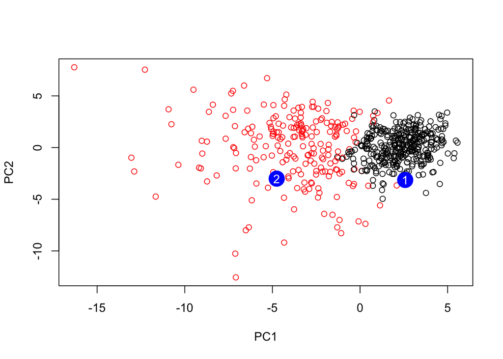

```r
plot(wisc.pr$x[,1:2], col=g)
points(npc[,1], npc[,2], col="blue", pch=16, cex=3)
text(npc[,1], npc[,2], c(1,2), col="white")
```

Q17. Which of these new patients should we prioritize for follow up based on your results? - Paitent number 2. RED IS MALIGNANT, BLACK IS BENIGN

# 8. PCA of protein sturcture data (Optional)

PCA of protein structure data Visit the Bio3D-web PCA app http://bio3d.ucsd.edu and explore how PCA of large protein structure sets can provide considerable insight into major features and trends with clear biological mechanistic insight. Note that the final report generated from this app contains all the R code required to run the analysis yourself - including PCA and clustering. We will delve more into this type of analysis in the next class.